# MBON Retrieval and Redeployment Cruise

June 16, 2026 *R/V Daiber* Lewes, DE

### Crew

- **Aaron Carlisle** *UD*
  - Chief Scientist
- **Michael Cyrana** *JHU-APL*
  - eDNA Lead
- **Tess Avery** *UD*
  - Acoustics and Biotelemetry Lead
- **Evan Falgowski** *UD*
  - Captain of *R/V Daiber*
- **Erin Duffy** *UD*
  - Field Technician

### Contact Information

- (831) 601-7461 | carlisle@udel.edu
- (443) 257-9276 | Michael.Cyrana@jhuapl.edu
- (617) 599-9681 | tmavery@udel.edu
- (610) 563-1040 | evanfal@udel.edu
- (617) 599-9681 | eadd@udel.edu

# Schedule, in brief

### 15 June

- Crew loads gear on *R/V Daiber*.

### 16 June

[interactive chart not shown]

# Cruise plan, calculated at 17 knots

- 06:00 Meet at *R/V Daiber*
- 06:30 Depart Lewes for **T-3C**
- **38 20.1636, -74 21.0288**
- 09:20 Arrive **T-3C**. Conduct eDNA sampling.
- 09:35 Once eDNA sampling is finished, retrieve current and redeploy new mooring.
- 09:55 Complete operations. Depart for **T-2C**
- **38 20.1648, -74 30.3072**
- 10:25 Arrive **T-2C**. Conduct eDNA sampling.
- 10:40 Once eDNA sampling is finished, retrieve current and redeploy new mooring (option 1) OR do not hotswap mooring until Sept cruise (option 2)
- 11:00 Complete operations. Depart for **MBON5**
- **38 20.1588, -74 34.656**
- 11:15 Arrive **MBON5**. Conduct eDNA sampling.
- 11:30 Once eDNA sampling is finished, retrieve current and redeploy new mooring.
- 11:50 Complete operations. Depart for **MBON4**
- **38 20.1714, -74 39.0138**
- 12:05 Arrive **MBON4**. Conduct eDNA sampling.
- 12:20 Once eDNA sampling is finished, retrieve current and redeploy new mooring.
- 12:40 Complete operations. Depart for **A-5C**
- **38 20.1582, -74 43.3752**
- 12:55 Arrive **A-5C**. Conduct eDNA sampling.
- 13:10 Once eDNA sampling is finished, retrieve current and redeploy new mooring.
- 13:30 Complete operations. Depart for **MBON3**
- **38 20.157, -74 47.9034**
- 13:45 Arrive **MBON3**. Conduct eDNA sampling.
- 14:00 Once eDNA sampling is finished, retrieve current and redeploy new mooring.
- 14:20 Complete operations. Depart for **MBON2**
- **38 20.1696, -74 52.4112**
- 14:35 Arrive **MBON2**. Conduct eDNA sampling.
- 14:50 Once eDNA sampling is finished, retrieve current and redeploy new mooring.
- 15:10 Complete operations. Depart for **T-1C**
- **38 20.1378, -74 56.946**
- 15:25 Arrive **T-1C**. Conduct eDNA sampling.
- 15:40 Once eDNA sampling is finished, retrieve current and redeploy new mooring.
- 16:00 Complete operations. Depart for **MBON1**
- **38 20.1576, -75 0.8886**
- 16:15 Arrive **MBON1**. Conduct eDNA sampling.
- 16:30 Once eDNA sampling is finished, retrieve current and redeploy new mooring with recovered VR2AR from T-2C (option 1) OR VR2AR prepped in lab (option 2)
- 16:50 Complete operations. Depart for **Lewes**

# Distances

Distance, nautical miles

|  | Lewes | T-3C | T-2C | MBON5 | MBON4 | A-5C | MBON3 | MBON2 | T-1C | MBON1 |
| --- | --- | --- | --- | --- | --- | --- | --- | --- | --- | --- |
| Lewes | 0.00 | 47.22 | 41.67 | 39.27 | 37.01 | 34.95 | 33.04 | 31.41 | 30.15 | 29.30 |
| T-3C | 47.22 | 0.00 | 7.28 | 10.70 | 14.12 | 17.54 | 21.09 | 24.63 | 28.19 | 31.29 |
| T-2C | 41.67 | 7.28 | 0.00 | 3.41 | 6.83 | 10.26 | 13.81 | 17.35 | 20.91 | 24.00 |
| MBON5 | 39.27 | 10.70 | 3.41 | 0.00 | 3.42 | 6.84 | 10.40 | 13.94 | 17.50 | 20.59 |
| MBON4 | 37.01 | 14.12 | 6.83 | 3.42 | 0.00 | 3.42 | 6.98 | 10.52 | 14.08 | 17.17 |
| A-5C | 34.95 | 17.54 | 10.26 | 6.84 | 3.42 | 0.00 | 3.55 | 7.09 | 10.65 | 13.75 |
| MBON3 | 33.04 | 21.09 | 13.81 | 10.40 | 6.98 | 3.55 | 0.00 | 3.54 | 7.10 | 10.19 |
| MBON2 | 31.41 | 24.63 | 17.35 | 13.94 | 10.52 | 7.09 | 3.54 | 0.00 | 3.56 | 6.65 |
| T-1C | 30.15 | 28.19 | 20.91 | 17.50 | 14.08 | 10.65 | 7.10 | 3.56 | 0.00 | 3.09 |
| MBON1 | 29.30 | 31.29 | 24.00 | 20.59 | 17.17 | 13.75 | 10.19 | 6.65 | 3.09 | 0.00 |

Distance, time at 17 kts

|  | Lewes | T-3C | T-2C | MBON5 | MBON4 | A-5C | MBON3 | MBON2 | T-1C | MBON1 |
| --- | --- | --- | --- | --- | --- | --- | --- | --- | --- | --- |
| Lewes | - | 02 h 50 m | 02 h 30 m | 02 h 20 m | 02 h 15 m | 02 h 05 m | 02 h 00 m | 01 h 55 m | 01 h 50 m | 01 h 45 m |
| T-3C | 02 h 50 m | - | 00 h 30 m | 00 h 40 m | 00 h 50 m | 01 h 05 m | 01 h 15 m | 01 h 30 m | 01 h 40 m | 01 h 55 m |
| T-2C | 02 h 30 m | 00 h 30 m | - | 00 h 15 m | 00 h 25 m | 00 h 40 m | 00 h 50 m | 01 h 05 m | 01 h 15 m | 01 h 25 m |
| MBON5 | 02 h 20 m | 00 h 40 m | 00 h 15 m | - | 00 h 15 m | 00 h 25 m | 00 h 40 m | 00 h 50 m | 01 h 05 m | 01 h 15 m |
| MBON4 | 02 h 15 m | 00 h 50 m | 00 h 25 m | 00 h 15 m | - | 00 h 15 m | 00 h 25 m | 00 h 40 m | 00 h 50 m | 01 h 05 m |
| A-5C | 02 h 05 m | 01 h 05 m | 00 h 40 m | 00 h 25 m | 00 h 15 m | - | 00 h 15 m | 00 h 30 m | 00 h 40 m | 00 h 50 m |
| MBON3 | 02 h 00 m | 01 h 15 m | 00 h 50 m | 00 h 40 m | 00 h 25 m | 00 h 15 m | - | 00 h 15 m | 00 h 30 m | 00 h 40 m |
| MBON2 | 01 h 55 m | 01 h 30 m | 01 h 05 m | 00 h 50 m | 00 h 40 m | 00 h 30 m | 00 h 15 m | - | 00 h 15 m | 00 h 25 m |
| T-1C | 01 h 50 m | 01 h 40 m | 01 h 15 m | 01 h 05 m | 00 h 50 m | 00 h 40 m | 00 h 30 m | 00 h 15 m | - | 00 h 15 m |
| MBON1 | 01 h 45 m | 01 h 55 m | 01 h 25 m | 01 h 15 m | 01 h 05 m | 00 h 50 m | 00 h 40 m | 00 h 25 m | 00 h 15 m | - |

# Coordinates from Mar ’26 Deployment

| **Sites** | **Latitude** | **Longitude** | **Moored data types** | **Moored instruments** | **VR2AR Release # for retrieval** |
| --- | --- | --- | --- | --- | --- |
| **T-3C** | 38º 20.1636’ | -74º 21.0288’ | biotelemetry, **PAM** | VR2AR, **LS-1X** | 546475 |
| **T-2C** | 38º 20.1648’ | -74º 30.3072’ | biotelemetry | VR2AR | 546456 |
| MBON5 | 38º 20.1588’ | -74º 34.656’ | biotelemetry | VR2AR | 546471 |
| **MBON4** | 38º 20.1714’ | -74º 39.0138’ | biotelemetry, **PAM** | VR2AR, **LS-1X** | 546307 |
| **A-5C** | 38º 20.1582’ | -74º 43.3752’ | biotelemetry, **PAM** | VR2AR, **F-POD** | 547716 |
| MBON3 | 38º 20.157’ | -74º 47.9034’ | biotelemetry | VR2AR | 546309 |
| **MBON2** | 38º 20.1696’ | -74º 52.4112’ | biotelemetry | VR2AR | 546323 |
| **T-1C** | 38º 20.1378’ | -74º 56.946’ | biotelemetry, **PAM** | VR2AR, **F-POD** | 553509 |
| MBON1 | 38º 20.1576’ | -75º 0.8886’ | biotelemetry | VR2AR | 553506 |

# Retrieval Table

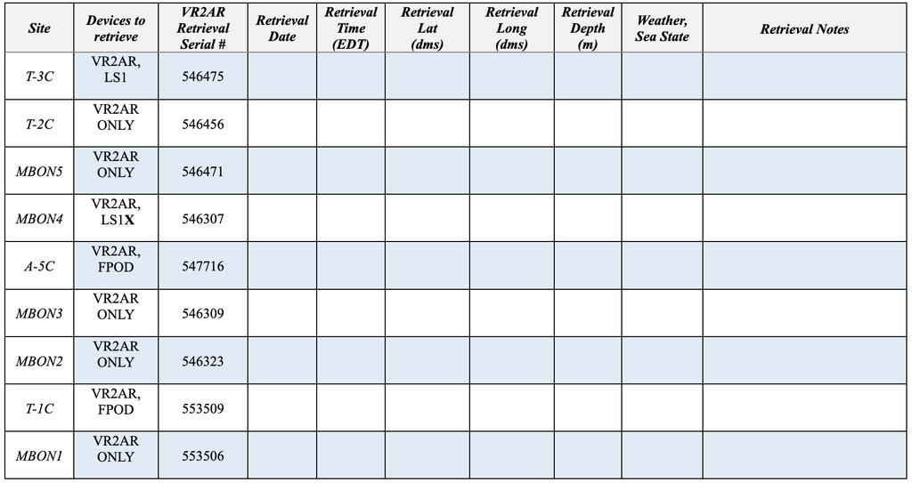

# Deployment Table

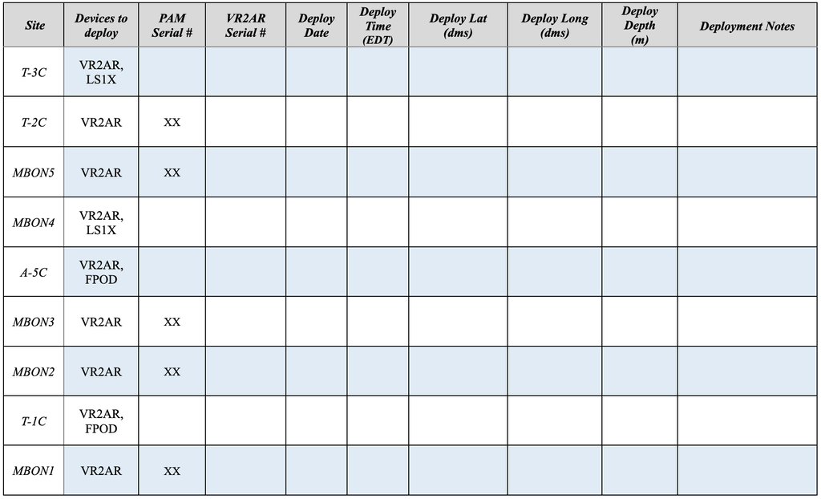

# Mooring Configurations

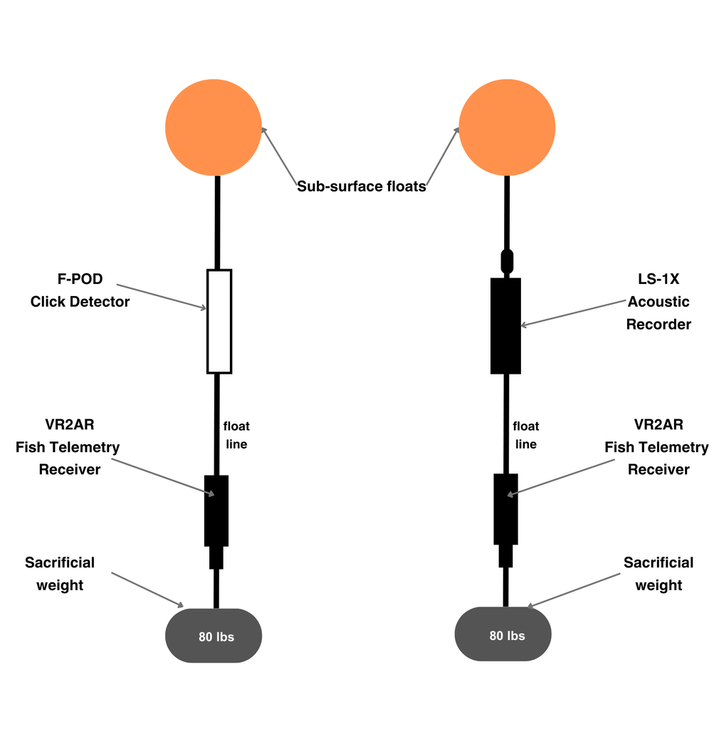

# PAM Device Set-up

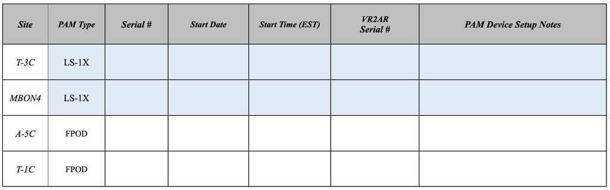

# Supply List

🔲 8 VR2ARs

🔲 2 F-PODs

🔲 2 LS-1Xs

🔲 9 large subsurface buoys

🔲 9 anchor lines

🔲 1 mooring set-up (buoy + line) for VR2AR only site

🔲 18 sacrificial 45lb weight plates (ranging 80-100 lb) - already at UD campus

🔲 Zip Ties - large, medium, and small sizes

🔲 Total of 68 D cell alkaline batteries - 48 for LS-1Xs and 20 for F-PODs

🔲 F-POD and LS-1X microsd memory cards

🔲 F-POD battery springs

🔲 Desiccant packets for PAM devices

🔲 F-POD opening rods

🔲 Garmin handheld GPS

🔲 Datasheets

🔲 Foul weather gear

🔲 Boat shoes

🔲 Life jackets

🔲 Sharpies

🔲 Toolbox

🔲 Work gloves

🔲 VR100 Deckbox (UD and UMCES spare)

🔲 VR100 Hydrophone (UD and UMCES spare)